# Home 5: Build a seq2seq model for machine translation.

### Name: Connor DePalma

### Task: Translate English to Italian

```python
# Needed for Colab
# from google.colab import drive
# drive.mount('/content/drive')
```

## 0. You will do the following:

1. Read and run my code.
2. Complete the code in Section 1.1 and Section 4.2.
   - Translation **English** to **German** is not acceptable!!! Try another pair of languages.
3. **Make improvements.** Directly modify the code in Section 3. Do at least one of the two. By doing both correctly, you will get up to 1 bonus score to the total.
   - Bi-LSTM instead of LSTM.
   - Attention. (You are allowed to use existing code.)
4. Evaluate the translation using the BLEU score.
   - Optional. Up to 1 bonus scores to the total.
5. Convert the notebook to .HTML file.
   - The HTML file must contain the code and the output after execution.
6. Put the .HTML file in your Google Drive, Dropbox, or Github repo. (If you submit the file to Google Drive or Dropbox, you must make the file "open-access". The delay caused by "deny of access" may result in late penalty.)
7. Submit the link to the HTML file to Canvas.

### Hint:

To implement `Bi-LSTM`, you will need the following code to build the encoder. Do NOT use Bi-LSTM for the decoder.

```python
# from keras.layers import Bidirectional, Concatenate

# encoder_bilstm = Bidirectional(LSTM(latent_dim, return_state=True,
#                                   dropout=0.5, name='encoder_lstm'))
# _, forward_h, forward_c, backward_h, backward_c = encoder_bilstm(encoder_inputs)

# state_h = Concatenate()([forward_h, backward_h])
# state_c = Concatenate()([forward_c, backward_c])
```

## 1. Data preparation

1. Download data (e.g., "deu-eng.zip") from http://www.manythings.org/anki/
2. Unzip the .ZIP file.
3. Put the .TXT file (e.g., "deu.txt") in the directory "./Data/".

### 1.1. Load and clean text

```python
import re
import string
from unicodedata import normalize
import numpy

# load doc into memory
def load_doc(filename):
    # open the file as read only
    file = open(filename, mode='rt', encoding='utf-8')
    # read all text
    text = file.read()
    # close the file
    file.close()
    return text


# split a loaded document into sentences
def to_pairs(doc):
    lines = doc.strip().split('\n')
    pairs = [line.split('\t') for line in  lines]
    return pairs

def clean_data(lines):
    cleaned = list()
    # prepare regex for char filtering
    re_print = re.compile('[^%s]' % re.escape(string.printable))
    # prepare translation table for removing punctuation
    table = str.maketrans('', '', string.punctuation)
    for pair in lines:
        clean_pair = list()
        for line in pair:
            # normalize unicode characters
            line = normalize('NFD', line).encode('ascii', 'ignore')
            line = line.decode('UTF-8')
            # tokenize on white space
            line = line.split()
            # convert to lowercase
            line = [word.lower() for word in line]
            # remove punctuation from each token
            line = [word.translate(table) for word in line]
            # remove non-printable chars form each token
            line = [re_print.sub('', w) for w in line]
            # remove tokens with numbers in them
            line = [word for word in line if word.isalpha()]
            # store as string
            clean_pair.append(' '.join(line))
        cleaned.append(clean_pair)
    return numpy.array(cleaned)
```

#### Fill the following blanks:

```python
# e.g., filename = 'Data/deu.txt'
filename = './Data/ita.txt'

# e.g., n_train = 20000
# total lines in file = 345,244
# memory issues occured frequently in colab
# couldn't utilize full dataset
n_train = 60000
n_test = 500
```

```python
# load dataset
doc = load_doc(filename)

# split into Language1-Language2 pairs
pairs = numpy.array(to_pairs(doc))

idx = numpy.random.permutation(len(pairs))

# clean sentences
clean_pairs = clean_data(pairs[idx])

# restrict number of characters to
# help with memory and computation time
temp = []
for pair in clean_pairs:
  if len(pair[0]) <= 70 and len(pair[1]) <= 70:
    temp.append(pair)

clean_pairs = numpy.array(temp)
train_pairs = clean_pairs[0:n_train, :]
test_pairs = clean_pairs[n_train:n_train+n_test, :]

# Clean mem
del pairs
del doc
```

```python
len(clean_pairs)
```

```
343043
```

```python
for i in range(3000, 3010):
    print('[' + train_pairs[i, 0] + '] => [' + train_pairs[i, 1] + ']')
```

```
[napoleon was exiled to st helena] => [napoleone fu esiliato a santelena]
[its kind of hot isnt it] => [fa piuttosto caldo vero]
[im older than you think] => [sono piu anziana di quanto pensate]
[i bought two dozen pencils] => [ho comprato due dozzine di matite]
[thats what i like about tom] => [e quello che mi piace di tom]
[do you see a rose] => [vedi una rosa]
[we cant be sure of that] => [non ne possiamo essere sicuri]
[the hamburger is a famous american dish] => [lhamburger e un famoso piatto americano]
[i have a lot of baggage so i cant walk home] => [io ho molti bagagli quindi non riesco ad andare a casa a piedi]
[how did you know tom wasnt the thief] => [come lo sapevi che tom non era il ladro]
```

```python
input_texts_train = train_pairs[:, 0]
target_texts_train = ['\t' + text + '\n' for text in train_pairs[:, 1]]

input_texts_test = test_pairs[:, 0]
target_texts_test = ['\t' + text + '\n' for text in test_pairs[:, 1]]

print('Length of training input_texts:  ' + str(input_texts_train.shape))
print('Length of training target_texts: ' + str(len(target_texts_train)))

print('Length of testing input_texts:  ' + str(input_texts_test.shape))
print('Length of testing target_texts: ' + str(len(target_texts_test)))

del train_pairs
del test_pairs
```

```
Length of training input_texts:  (60000,)
Length of training target_texts: 60000
Length of testing input_texts:  (500,)
Length of testing target_texts: 500
```

```python
max_encoder_seq_length = max(len(line) for line in input_texts_train)
max_decoder_seq_length = max(len(line) for line in target_texts_train)

max_encoder_test_seq_length = max(len(line) for line in input_texts_test)
max_decoder_test_seq_length = max(len(line) for line in target_texts_test)

print('max length of train input  sentences: %d' % (max_encoder_seq_length))
print('max length of train target sentences: %d' % (max_decoder_seq_length))

print('max length of test input  sentences: %d' % (max_encoder_test_seq_length))
print('max length of test target sentences: %d' % (max_decoder_test_seq_length))
```

```
max length of train input  sentences: 70
max length of train target sentences: 72
max length of test input  sentences: 60
max length of test target sentences: 72
```

**Remark:** To this end, you have two lists of sentences: input_texts and target_texts

## 2. Text processing

### 2.1. Convert texts to sequences

- Input: A list of $n$ sentences (with max length $t$).
- It is represented by a $n\times t$ matrix after the tokenization and zero-padding.

```python
from keras.preprocessing.text import Tokenizer
from keras.preprocessing.sequence import pad_sequences

# encode and pad sequences
def text2sequences(max_len, lines):
    tokenizer = Tokenizer(char_level=True, filters='')
    tokenizer.fit_on_texts(lines)
    seqs = tokenizer.texts_to_sequences(lines)
    seqs_pad = pad_sequences(seqs, maxlen=max_len, padding='post')
    return seqs_pad, tokenizer.word_index, tokenizer

# Capture encoder tokenizer to be used later for prediction and BLEU Scoring
encoder_input_seq, input_token_index, encode_tokenizer = text2sequences(max_encoder_seq_length,
                                                      input_texts_train)
decoder_input_seq, target_token_index, _ = text2sequences(max_decoder_seq_length,
                                                       target_texts_train)

print('shape of encoder_input_seq: ' + str(encoder_input_seq.shape))
print('shape of input_token_index: ' + str(len(input_token_index)))
print('shape of decoder_input_seq: ' + str(decoder_input_seq.shape))
print('shape of target_token_index: ' + str(len(target_token_index)))
```

```
shape of encoder_input_seq: (60000, 70)
shape of input_token_index: 27
shape of decoder_input_seq: (60000, 72)
shape of target_token_index: 29
```

```python
num_encoder_tokens = len(input_token_index) + 1
num_decoder_tokens = len(target_token_index) + 1

print('num_encoder_tokens: ' + str(num_encoder_tokens))
print('num_decoder_tokens: ' + str(num_decoder_tokens))
```

```
num_encoder_tokens: 28
num_decoder_tokens: 30
```

**Remark:** To this end, the input language and target language texts are converted to 2 matrices.

- Their number of rows are both n_train.
- Their number of columns are respective max_encoder_seq_length and max_decoder_seq_length.

The followings print a sentence and its representation as a sequence.

```python
target_texts_train[100]
```

```
'\tnon cerano leggi che dicevano quello che potevano o non potevano fare\n'
```

```python
decoder_input_seq[100, :]
```

```
array([11,  7,  2,  7,  1, 13,  4,  8,  3,  7,  2,  1, 10,  4, 20, 20,  5,
        1, 13, 19,  4,  1, 16,  5, 13,  4, 18,  3,  7,  2,  1, 23, 15,  4,
       10, 10,  2,  1, 13, 19,  4,  1, 17,  2,  6,  4, 18,  3,  7,  2,  1,
        2,  1,  7,  2,  7,  1, 17,  2,  6,  4, 18,  3,  7,  2,  1, 22,  3,
        8,  4, 12,  0], dtype=int32)
```

## 2.2. One-hot encode

- Input: A list of $n$ sentences (with max length $t$).
- It is represented by a $n\times t$ matrix after the tokenization and zero-padding.
- It is represented by a $n\times t \times v$ tensor ($t$ is the number of unique chars) after the one-hot encoding.

```python
from keras.utils import to_categorical

# one hot encode target sequence
def onehot_encode(sequences, max_len, vocab_size):
    n = len(sequences)
    data = numpy.zeros((n, max_len, vocab_size))
    for i in range(n):
        data[i, :, :] = to_categorical(sequences[i], num_classes=vocab_size)
    return data

encoder_input_data = onehot_encode(encoder_input_seq, max_encoder_seq_length, num_encoder_tokens)
decoder_input_data = onehot_encode(decoder_input_seq, max_decoder_seq_length, num_decoder_tokens)

decoder_target_seq = numpy.zeros(decoder_input_seq.shape)
decoder_target_seq[:, 0:-1] = decoder_input_seq[:, 1:]
decoder_target_data = onehot_encode(decoder_target_seq,
                                    max_decoder_seq_length,
                                    num_decoder_tokens)

print(encoder_input_data.shape)
print(decoder_input_data.shape)

del encoder_input_seq
del decoder_input_seq
```

```
(60000, 70, 28)
(60000, 72, 30)
```

## 3. Build the networks (for training)

- Build encoder, decoder, and connect the two modules to get "model".
- Fit the model on the bilingual data to train the parameters in the encoder and decoder.

### 3.1. Encoder network

- Input: one-hot encode of the input language
- Return:

  -- the final hidden state $h_t$

  -- the final conveyor belt $c_t$

```python
from keras.layers import Input, LSTM, Bidirectional, Concatenate, Attention
from keras.models import Model

latent_dim = 256

# inputs of the encoder network
encoder_inputs = Input(shape=(None, num_encoder_tokens),
                       name='encoder_inputs')

# set the Bi-LSTM layer
encoder_bilstm = Bidirectional(LSTM(latent_dim, return_state=True, return_sequences=True,
                                  dropout=0.5, name='encoder_lstm'))
allh, forward_h, forward_c, backward_h, backward_c = encoder_bilstm(encoder_inputs)


state_h = Concatenate()([forward_h, backward_h])
state_c = Concatenate()([forward_c, backward_c])

# build the encoder network model
encoder_model = Model(inputs=encoder_inputs,
                      outputs=[allh, state_h, state_c],
                      name='encoder')
```

Print a summary and save the encoder network structure to "./encoder.pdf"

```python
from IPython.display import SVG
from keras.utils.vis_utils import model_to_dot, plot_model

SVG(model_to_dot(encoder_model, show_shapes=False).create(prog='dot', format='svg'))

plot_model(
    model=encoder_model, show_shapes=False,
    to_file='encoder.pdf'
)

encoder_model.summary()
```

```
Model: "encoder"
__________________________________________________________________________________________________
Layer (type)                    Output Shape         Param #     Connected to
==================================================================================================
encoder_inputs (InputLayer)     [(None, None, 28)]   0
__________________________________________________________________________________________________
bidirectional (Bidirectional)   [(None, None, 512),  583680      encoder_inputs[0][0]
__________________________________________________________________________________________________
concatenate (Concatenate)       (None, 512)          0           bidirectional[0][1]
                                                                 bidirectional[0][3]
__________________________________________________________________________________________________
concatenate_1 (Concatenate)     (None, 512)          0           bidirectional[0][2]
                                                                 bidirectional[0][4]
==================================================================================================
Total params: 583,680
Trainable params: 583,680
Non-trainable params: 0
__________________________________________________________________________________________________
```

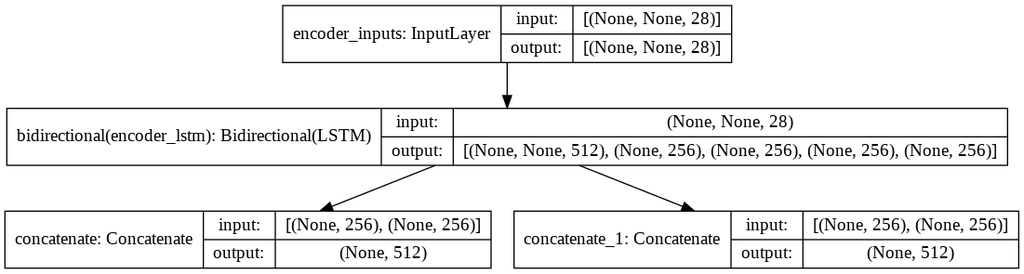

```python
plot_model(encoder_model,show_shapes=True)
```

### 3.2. Decoder network (w/ Attention)

- Inputs:

  -- one-hot encode of the target language

  -- The initial h_t$

  -- The initial conveyor belt $c_t$
- Return:

  -- output (all the hidden states) $h_1, \cdots , h_t$

  -- the final hidden state $h_t$ (discarded in the training and used in the prediction)

  -- the final conveyor belt $c_t$ (discarded in the training and used in the prediction)

```python
from keras.layers import Input, LSTM, Dense, concatenate
from keras.layers import dot, Activation, BatchNormalization
from keras.models import Model

# inputs of the decoder network
decoder_input_x = Input(shape=(None, num_decoder_tokens), name='decoder_input_allh')
decoder_input_h = Input(shape=(latent_dim*2,), name='decoder_input_h')
decoder_input_c = Input(shape=(latent_dim*2,), name='decoder_input_c')
encode_allh = Input(shape=(None, latent_dim*2,), name='encode_allh')

# set the LSTM layer
decoder_lstm = LSTM(latent_dim*2, return_sequences=True,
                    return_state=True, dropout=0.5, name='decoder_lstm')
decoder_lstm_outputs, state_h, state_c = decoder_lstm(decoder_input_x, initial_state=[decoder_input_h, decoder_input_c])

# add attention
attention = dot([decoder_lstm_outputs, encode_allh], axes=[2,2])
attention = Activation('softmax')(attention)

context = dot([attention, encode_allh], axes=[2,1])

decode_context = concatenate([context, decoder_lstm_outputs])

# set the dense layer
decoder_dense = Dense(num_decoder_tokens, activation='softmax', name='decoder_dense')
decoder_outputs = decoder_dense(decode_context)

# build the decoder network model
decoder_model = Model(inputs=[decoder_input_x, decoder_input_h, decoder_input_c, encode_allh],
                      outputs=[decoder_outputs, state_h, state_c],
                      name='decoder')
```

```python
decoder_input_h, decoder_input_c
```

```
(<KerasTensor: shape=(None, 512) dtype=float32 (created by layer 'decoder_input_h')>,
 <KerasTensor: shape=(None, 512) dtype=float32 (created by layer 'decoder_input_c')>)
```

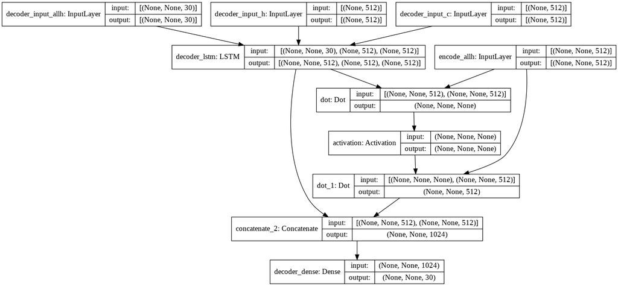

```python
plot_model(decoder_model, show_shapes=True)
```

Print a summary and save the encoder network structure to "./decoder.pdf"

```python
from IPython.display import SVG
from keras.utils.vis_utils import model_to_dot, plot_model

SVG(model_to_dot(decoder_model, show_shapes=False).create(prog='dot', format='svg'))

plot_model(
    model=decoder_model, show_shapes=False,
    to_file='decoder.pdf'
)

decoder_model.summary()
```

```
Model: "decoder"
__________________________________________________________________________________________________
Layer (type)                    Output Shape         Param #     Connected to
==================================================================================================
decoder_input_allh (InputLayer) [(None, None, 30)]   0
__________________________________________________________________________________________________
decoder_input_h (InputLayer)    [(None, 512)]        0
__________________________________________________________________________________________________
decoder_input_c (InputLayer)    [(None, 512)]        0
__________________________________________________________________________________________________
decoder_lstm (LSTM)             [(None, None, 512),  1112064     decoder_input_allh[0][0]
                                                                 decoder_input_h[0][0]
                                                                 decoder_input_c[0][0]
__________________________________________________________________________________________________
encode_allh (InputLayer)        [(None, None, 512)]  0
__________________________________________________________________________________________________
dot (Dot)                       (None, None, None)   0           decoder_lstm[0][0]
                                                                 encode_allh[0][0]
__________________________________________________________________________________________________
activation (Activation)         (None, None, None)   0           dot[0][0]
__________________________________________________________________________________________________
dot_1 (Dot)                     (None, None, 512)    0           activation[0][0]
                                                                 encode_allh[0][0]
__________________________________________________________________________________________________
concatenate_2 (Concatenate)     (None, None, 1024)   0           dot_1[0][0]
                                                                 decoder_lstm[0][0]
__________________________________________________________________________________________________
decoder_dense (Dense)           (None, None, 30)     30750       concatenate_2[0][0]
==================================================================================================
Total params: 1,142,814
Trainable params: 1,142,814
Non-trainable params: 0
__________________________________________________________________________________________________
```

### 3.3. Connect the encoder and decoder

```python
import tensorflow as tf
from keras.layers import BatchNormalization
# input layers
encoder_input_x = Input(shape=(None, num_encoder_tokens), name='encoder_input_x')
decoder_input_x = Input(shape=(None, num_decoder_tokens), name='decoder_input_x')


# connect encoder to decoder
allh, h, c = encoder_model([encoder_input_x])

decoder_pred, _, _ = decoder_model([decoder_input_x, h, c, allh])
# decoder_lstm_output, _, _ = decoder_lstm(decoder_input_x, initial_state=[h,c])
# decoder_pred = decoder_dense(decoder_lstm_output)

model = Model(inputs=[encoder_input_x, decoder_input_x],
              outputs=decoder_pred,
              name='model_training')
```

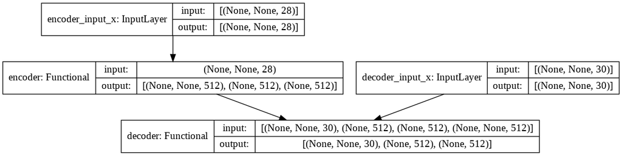

```python
plot_model(model,show_shapes=True)
```

```python
print(state_h)
print(decoder_input_h)
```

```
KerasTensor(type_spec=TensorSpec(shape=(None, 512), dtype=tf.float32, name=None), name='decoder_lstm/PartitionedCall:2', description="created by layer 'decoder_lstm'")
KerasTensor(type_spec=TensorSpec(shape=(None, 512), dtype=tf.float32, name='decoder_input_h'), name='decoder_input_h', description="created by layer 'decoder_input_h'")
```

```python
from IPython.display import SVG
from keras.utils.vis_utils import model_to_dot, plot_model

SVG(model_to_dot(model, show_shapes=False).create(prog='dot', format='svg'))

plot_model(
    model=model, show_shapes=False,
    to_file='model_training.pdf'
)

model.summary()
```

```
Model: "model_training"
__________________________________________________________________________________________________
Layer (type)                    Output Shape         Param #     Connected to
==================================================================================================
encoder_input_x (InputLayer)    [(None, None, 28)]   0
__________________________________________________________________________________________________
decoder_input_x (InputLayer)    [(None, None, 30)]   0
__________________________________________________________________________________________________
encoder (Functional)            [(None, None, 512),  583680      encoder_input_x[0][0]
__________________________________________________________________________________________________
decoder (Functional)            [(None, None, 30), ( 1142814     decoder_input_x[0][0]
                                                                 encoder[0][1]
                                                                 encoder[0][2]
                                                                 encoder[0][0]
==================================================================================================
Total params: 1,726,494
Trainable params: 1,726,494
Non-trainable params: 0
__________________________________________________________________________________________________
```

### 3.5. Fit the model on the bilingual dataset

- encoder_input_data: one-hot encode of the input language
- decoder_input_data: one-hot encode of the input language
- decoder_target_data: labels (left shift of decoder_input_data)
- tune the hyper-parameters
- stop when the validation loss stop decreasing.

```python
print('shape of encoder_input_data' + str(encoder_input_data.shape))
print('shape of decoder_input_data' + str(decoder_input_data.shape))
print('shape of decoder_target_data' + str(decoder_target_data.shape))
```

```
shape of encoder_input_data(60000, 70, 28)
shape of decoder_input_data(60000, 72, 30)
shape of decoder_target_data(60000, 72, 30)
```

```python
model.compile(optimizer='rmsprop', loss='categorical_crossentropy')

model.fit([encoder_input_data, decoder_input_data],  # training data
          decoder_target_data,                       # labels (left shift of the target sequences)
          batch_size=64, epochs=75, validation_split=0.2)

model.save('seq2seq.h5')
```

## 4. Make predictions

### 4.1. Translate English to Italian

1. Encoder read a sentence (source language) and output its final states, $h_t$ and $c_t$.
2. Take the [start] sign "\t" and the final state $h_t$ and $c_t$ as input and run the decoder.
3. Get the new states and predicted probability distribution.
4. sample a char from the predicted probability distribution
5. take the sampled char and the new states as input and repeat the process (stop if reach the [stop] sign "\n").

```python
# Reverse-lookup token index to decode sequences back to something readable.
reverse_input_char_index = dict((i, char) for char, i in input_token_index.items())
reverse_target_char_index = dict((i, char) for char, i in target_token_index.items())
```

```python
def decode_sequence(input_seq):
    allh, h,c = encoder_model.predict(input_seq)
    states_value = [h,c] + allh

    target_seq = numpy.zeros((1, 1, num_decoder_tokens))
    target_seq[0, 0, target_token_index['\t']] = 1.

    # print( target_seq.shape, h.shape, c.shape, allh.shape, states_value.shape)
    stop_condition = False
    decoded_sentence = ''
    temperature = 0.2
    while not stop_condition:
        output_tokens, h, c = decoder_model.predict([target_seq,h,c,allh])

        # this line of code is greedy selection
        # try to use multinomial sampling instead (with temperature)
        # sampled_token_index = numpy.argmax(output_tokens[0, -1, :])
        pred = output_tokens[0,-1,:] ** (1/temperature)
        # need to cast to float64 since output of model is float32
        # and rounding errors could make it so the pvals parameter in
        # multinomial is greater than 1
        # see here: https://github.com/numpy/numpy/issues/8317
        pred = pred.astype(numpy.float64)
        pred = pred / numpy.sum(pred)
        next_onehot = numpy.random.multinomial(1,pred)
        sampled_token_index = numpy.argmax(next_onehot)

        # If test data contains unknown tokens, end the decoding short
        # Otherwise this breaks the BLEU Score code
        sampled_char = '\n'
        if sampled_token_index in reverse_target_char_index:
          sampled_char = reverse_target_char_index[sampled_token_index]

        decoded_sentence += sampled_char

        if (sampled_char == '\n' or
           len(decoded_sentence) > max_decoder_seq_length):
            stop_condition = True

        target_seq = numpy.zeros((1, 1, num_decoder_tokens))
        target_seq[0, 0, sampled_token_index] = 1.

        # states_value = [h, c]

    return decoded_sentence
```

```python
for seq_index in range(2100, 2120):
    # Take one sequence (part of the training set)
    # for trying out decoding.
    input_seq = encoder_input_data[seq_index: seq_index + 1]
    decoded_sentence = decode_sequence(input_seq)
    print('-')
    print('English:       ', input_texts_train[seq_index])
    print('Italian (true): ', target_texts_train[seq_index][1:-1])
    print('Italian (pred): ', decoded_sentence[0:-1])
```

```
-
English:        dogs often bury bones
Italian (true):  i cani sotterrano spesso delle ossa
Italian (pred):  i datti sono spesso la sola
-
English:        she quit her job for some reason
Italian (true):  ha lasciato il suo lavoro per una qualche ragione
Italian (pred):  lei ha rascotto il suo lavoro per qualche passone
-
English:        i loved the movie
Italian (true):  io ho amato il film
Italian (pred):  amovai la folma
-
English:        you should leave tom
Italian (true):  dovresti partire tom
Italian (pred):  dovresti andare a trovare tom
-
English:        who invited you to the party
Italian (true):  chi vi ha invitate alla festa
Italian (pred):  chi ha invitato alla festa
-
English:        if you tell the truth you dont have to remember anything
Italian (true):  se dice la verita non deve ricordare niente
Italian (pred):  se dice la verita di cenare non ho datto nulla
-
English:        im going to miss you so much
Italian (true):  mi mancherete cosi tanto
Italian (pred):  io mi manchero cosi tanto
-
English:        tom prefers to stay home
Italian (true):  tom preferisce stare a casa
Italian (pred):  tom preferisce di restare a casa
-
English:        were you playing tennis yesterday morning
Italian (true):  stavate giocando a tennis ieri mattina
Italian (pred):  stava giocando a tannis ieri mamettina
-
English:        you are blushing
Italian (true):  lei sta arrossendo
Italian (pred):  sta discussndo
```

[output cut: 25 more lines]

```
English:        i am in the house
Italian (true):  io sono in casa
Italian (pred):  sono in casa
-
English:        that doesnt have to happen
Italian (true):  non deve succedere
Italian (pred):  non deve capitere
-
English:        i think tom is greedy
Italian (true):  io penso che tom sia taccagno
Italian (pred):  io penso che tom sia grando
-
English:        he closed his eyes
Italian (true):  ha chiuso gli occhi
Italian (pred):  lui ha cuosato la sua sicina
```

### 4.2. Translate an English sentence to the target language

1. Tokenization
2. One-hot encode
3. Translate

```python
input_sentence = 'I love you'


input_sequence = encode_tokenizer.texts_to_sequences([input_sentence])
input_sequence = pad_sequences(input_sequence, maxlen=max_encoder_seq_length, padding='post')

input_x = onehot_encode(input_sequence, max_encoder_seq_length, num_encoder_tokens)

translated_sentence = decode_sequence(input_x)

print('source sentence is: ' + input_sentence)
print('translated sentence is: ' + translated_sentence)
```

```
source sentence is: I love you
translated sentence is: ai amo
```

```python
input_sequence
```

```
array([[ 5,  1, 12,  4, 23,  2,  1, 13,  4, 15,  0,  0,  0,  0,  0,  0,
         0,  0,  0,  0,  0,  0,  0,  0,  0,  0,  0,  0,  0,  0,  0,  0,
         0,  0,  0,  0,  0,  0,  0,  0,  0,  0,  0,  0,  0,  0,  0,  0,
         0,  0,  0,  0,  0,  0,  0,  0,  0,  0,  0,  0,  0,  0,  0,  0,
         0,  0,  0,  0,  0,  0]], dtype=int32)
```

## 5. Evaluate the translation using BLEU score

Reference:

- https://machinelearningmastery.com/calculate-bleu-score-for-text-python/
- https://en.wikipedia.org/wiki/BLEU

**Hint:**

- Randomly partition the dataset to training, validation, and test.
- Evaluate the BLEU score using the test set. Report the average.
- A reasonable BLEU score should be 0.1 ~ 0.5.

```python
# Prepare Test data
# Done in a similar fashion to how training data was prepared
test_sequences = encode_tokenizer.texts_to_sequences(input_texts_test)
test_sequences = pad_sequences(test_sequences, maxlen=max_encoder_test_seq_length, padding='post')

input_test = onehot_encode(test_sequences, max_encoder_test_seq_length, num_encoder_tokens)
```

```python
from nltk.translate.bleu_score import sentence_bleu

score = 0
for i in range(len(input_test)):
  # Prepare Candidate
  translated = decode_sequence(input_test[i:i+1])
  translated = translated.strip().split(" ")

  # Prepare References
  ref = []
  for sentence in clean_pairs:
    if sentence[0] == input_texts_test[i]:
      ref.append(sentence[1].strip().split(" "))

  score += sentence_bleu(ref,translated)

score /= len(input_test)
```

```python
print(f"Average BLEU Score is: {score}")
```

```
Average BLEU Score is: 0.5697618866869706
```